# Diamonds Price Estimation

## The library and data are loading

```r
set.seed(503)
library(tidyverse)
library(knitr)
```

```r
library(dplyr)
library(ggplot2)
diamonds_test <- diamonds %>% mutate(diamond_id = row_number()) %>%
group_by(cut, color, clarity) %>% sample_frac(0.2) %>% ungroup()
diamonds_train <- anti_join(diamonds %>% mutate(diamond_id = row_number()),
diamonds_test, by = "diamond_id")
```

## Looking at which variables affect price

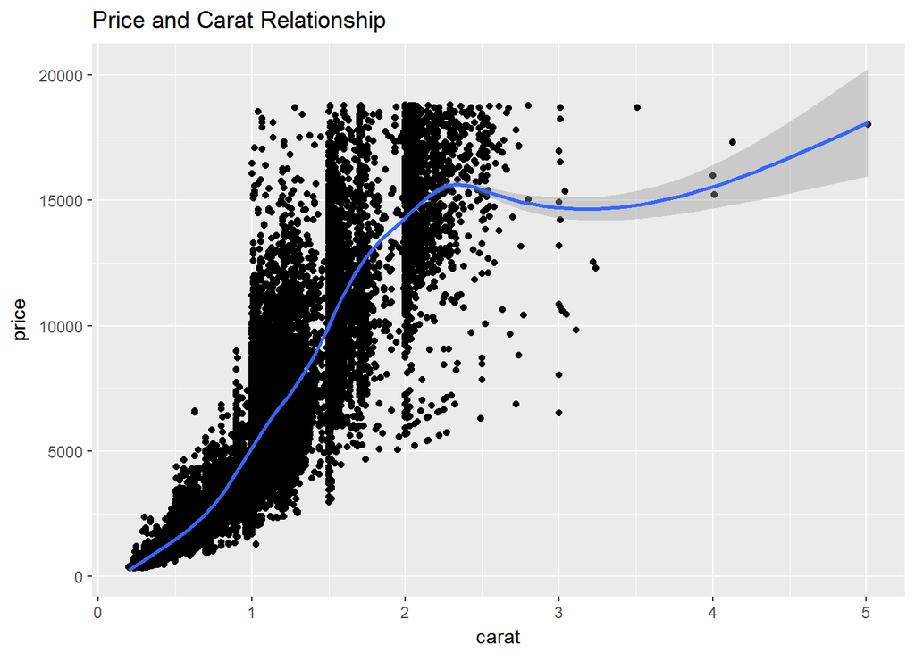

```r
    ggplot(aes(x=carat,y=price),data=diamonds_train) +   geom_point() + geom_smooth() +
   ggtitle('Price and Carat Relationship')
```

In chart aboved mentioned, there is a direct relationship between carat and price, as carat increases, prices also increases.

Also we have to look at the other varibales such as cut,color and clarity as well as carat.

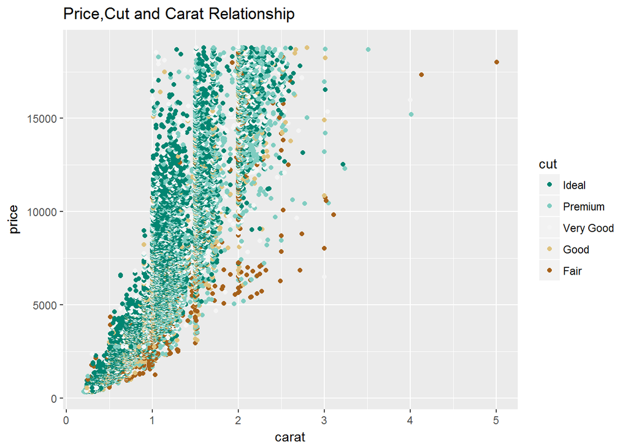

```r
    ggplot(aes(x=carat,y=price),data=diamonds_train) +   geom_point(aes(color=cut)) + scale_color_brewer(type = 'div',
    guide = guide_legend(reverse = T))  +
   ggtitle('Price,Cut and Carat Relationship')
```

In chart aboved mentioned, Cut of a diamond changes the price. if the cut of a diamond is ideal and premium, price will increase. In other words, if the cut of a dimamond is good and fair, price will decrease.

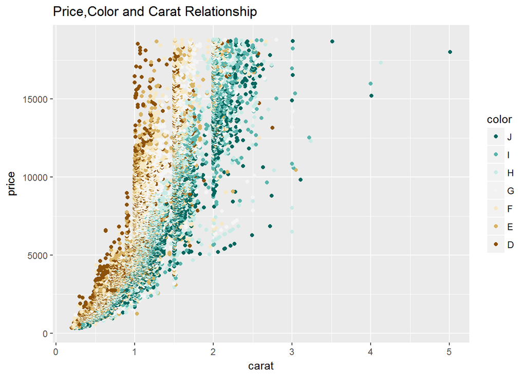

```r
    ggplot(aes(x=carat,y=price),data=diamonds_train) +   geom_point(aes(color=color)) + scale_color_brewer(type = 'div',
    guide = guide_legend(reverse = T))  +
   ggtitle('Price,Color and Carat Relationship')
```

In chart aboved mentioned, color of a diamond changes the price. if the color of a diamond is D and E, price will increase. In other words, if the coloer of a dimamond is J and I, price will decrease.

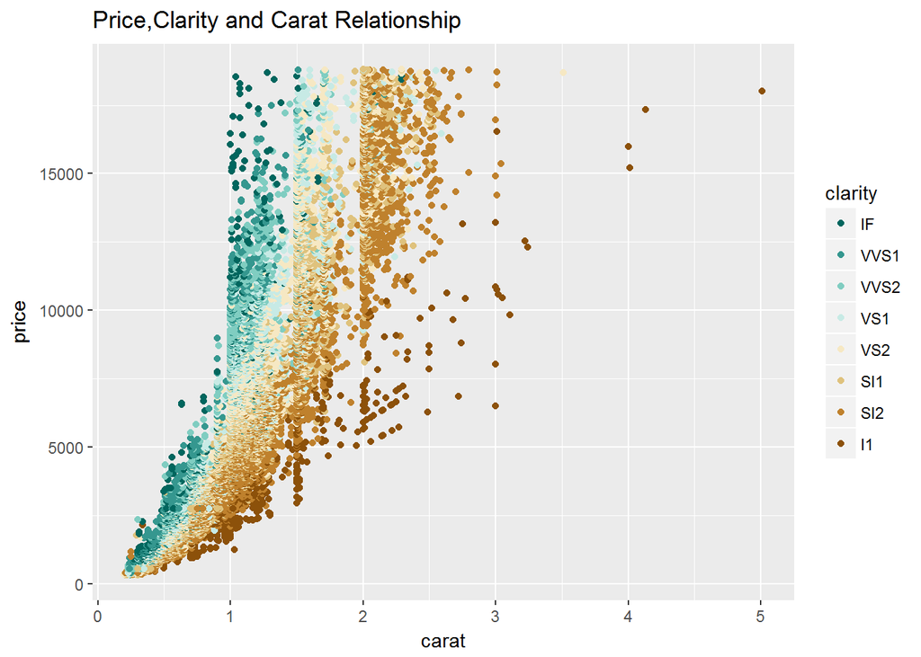

```r
  ggplot(aes(x=carat,y=price),data=diamonds_train) +   geom_point(aes(color=clarity)) + scale_color_brewer(type = 'div',
    guide = guide_legend(reverse = T))  +
   ggtitle('Price,Clarity and Carat Relationship')
```

## Linear Model

The model is creating.

```r
model <- lm(log10(price) ~log10(carat) + cut+color+clarity, data = diamonds_train)

summary(model)
```

```
##
## Call:
## lm(formula = log10(price) ~ log10(carat) + cut + color + clarity,
##     data = diamonds_train)
##
## Residuals:
##      Min       1Q   Median       3Q      Max
## -0.43975 -0.03739 -0.00014  0.03618  0.84540
##
## Coefficients:
##                Estimate Std. Error  t value Pr(>|t|)
## (Intercept)   3.6729978  0.0005670 6477.833  < 2e-16 ***
## log10(carat)  1.8843104  0.0012603 1495.166  < 2e-16 ***
## cut.L         0.0522537  0.0011416   45.773  < 2e-16 ***
## cut.Q        -0.0152879  0.0010048  -15.214  < 2e-16 ***
## cut.C         0.0060017  0.0008723    6.881 6.04e-12 ***
## cut^4        -0.0009283  0.0006984   -1.329    0.184
## color.L      -0.1913851  0.0009832 -194.661  < 2e-16 ***
## color.Q      -0.0413600  0.0009030  -45.801  < 2e-16 ***
## color.C      -0.0060990  0.0008449   -7.219 5.34e-13 ***
## color^4       0.0049564  0.0007759    6.388 1.70e-10 ***
## color^5      -0.0007820  0.0007332   -1.067    0.286
## color^6       0.0006871  0.0006663    1.031    0.302
## clarity.L     0.3973321  0.0017360  228.883  < 2e-16 ***
## clarity.Q    -0.1059695  0.0016162  -65.566  < 2e-16 ***
## clarity.C     0.0566246  0.0013851   40.882  < 2e-16 ***
## clarity^4    -0.0282896  0.0011074  -25.546  < 2e-16 ***
## clarity^5     0.0119068  0.0009037   13.176  < 2e-16 ***
## clarity^6    -0.0005438  0.0007869   -0.691    0.490
## clarity^7     0.0146968  0.0006941   21.175  < 2e-16 ***
## ---
## Signif. codes:  0 '***' 0.001 '**' 0.01 '*' 0.05 '.' 0.1 ' ' 1
##
## Residual standard error: 0.05799 on 43124 degrees of freedom
## Multiple R-squared:  0.9827, Adjusted R-squared:  0.9827
## F-statistic: 1.361e+05 on 18 and 43124 DF,  p-value: < 2.2e-16
```

#### Model Interpreting

Model mentioned above explains %98 of the variance. It has highly significant overall model p-value.  
Since the model has smaller average, 0.00014, the model is better. In additon, p value is lower than 0.05, so it is significant.

#### Model Testing

```r
diamonds_test_yeni<-diamonds_test %>%
  select(carat,cut,color,clarity)

estimate <- predict(model,diamonds_test,
                    level = .95)

predict_result<- round(10^estimate)
result<- data.frame(diamonds_test %>% select(carat,cut,color,clarity,price),predict_result)

result<-result %>% mutate(PriceDifference=abs(round(price-predict_result)), PriceDifferencePercentage=abs(round((price/predict_result-1)*100,2))) %>% arrange(PriceDifferencePercentage)
```

#### The top 20 best predicted diamonds

```r
kable(result %>%filter(row_number()<=20)  )
```

| carat | cut | color | clarity | price | predict_result | PriceDifference | PriceDifferencePercentage |
| --- | --- | --- | --- | --- | --- | --- | --- |
| 0.33 | Good | G | VS1 | 666 | 666 | 0 | 0 |
| 0.32 | Very Good | F | VS1 | 696 | 696 | 0 | 0 |
| 0.23 | Very Good | F | VS1 | 373 | 373 | 0 | 0 |
| 1.53 | Very Good | G | SI2 | 8455 | 8455 | 0 | 0 |
| 0.32 | Very Good | H | VVS1 | 730 | 730 | 0 | 0 |
| 0.32 | Very Good | H | VVS1 | 730 | 730 | 0 | 0 |
| 0.31 | Premium | F | VS2 | 625 | 625 | 0 | 0 |
| 0.31 | Premium | F | VS2 | 625 | 625 | 0 | 0 |
| 0.53 | Premium | G | SI2 | 1173 | 1173 | 0 | 0 |
| 0.70 | Premium | H | SI2 | 1808 | 1808 | 0 | 0 |
| 0.32 | Ideal | E | VS1 | 758 | 758 | 0 | 0 |
| 0.33 | Ideal | E | VVS1 | 986 | 986 | 0 | 0 |
| 0.70 | Ideal | F | SI1 | 2551 | 2551 | 0 | 0 |
| 0.31 | Ideal | G | SI2 | 436 | 436 | 0 | 0 |
| 0.31 | Ideal | G | VS1 | 642 | 642 | 0 | 0 |
| 0.54 | Ideal | G | VVS2 | 2090 | 2090 | 0 | 0 |
| 0.32 | Ideal | G | IF | 918 | 918 | 0 | 0 |
| 0.32 | Ideal | G | IF | 918 | 918 | 0 | 0 |
| 0.32 | Ideal | G | IF | 918 | 918 | 0 | 0 |
| 0.32 | Ideal | G | IF | 918 | 918 | 0 | 0 |

```r
resultRowNumber <- nrow(result) -20

kable(result %>%filter(row_number()>=resultRowNumber)  )
```

| carat | cut | color | clarity | price | predict_result | PriceDifference | PriceDifferencePercentage |
| --- | --- | --- | --- | --- | --- | --- | --- |
| 1.01 | Ideal | H | SI2 | 5828 | 3686 | 2142 | 58.11 |
| 1.00 | Fair | D | VVS2 | 10562 | 6673 | 3889 | 58.28 |
| 0.26 | Very Good | D | SI1 | 658 | 415 | 243 | 58.55 |
| 0.96 | Fair | J | I1 | 2304 | 1438 | 866 | 60.22 |
| 0.23 | Very Good | D | SI2 | 449 | 279 | 170 | 60.93 |
| 0.48 | Very Good | J | SI2 | 1080 | 670 | 410 | 61.19 |
| 1.03 | Good | H | SI2 | 5768 | 3530 | 2238 | 63.40 |
| 0.23 | Ideal | H | VS2 | 512 | 311 | 201 | 64.63 |
| 1.50 | Very Good | G | VS2 | 18691 | 11165 | 7526 | 67.41 |
| 1.00 | Ideal | D | VVS1 | 14498 | 8403 | 6095 | 72.53 |
| 1.09 | Very Good | D | IF | 18231 | 10388 | 7843 | 75.50 |
| 1.01 | Premium | D | IF | 16234 | 9203 | 7031 | 76.40 |
| 1.01 | Very Good | D | IF | 16087 | 8998 | 7089 | 78.78 |
| 1.03 | Ideal | D | IF | 17590 | 9758 | 7832 | 80.26 |
| 1.00 | Good | D | IF | 15928 | 8517 | 7411 | 87.01 |
| 0.34 | Ideal | D | IF | 2346 | 1209 | 1137 | 94.04 |
| 0.34 | Ideal | D | IF | 2346 | 1209 | 1137 | 94.04 |
| 0.35 | Fair | G | VS2 | 1415 | 640 | 775 | 121.09 |
| 0.35 | Fair | G | VS2 | 1415 | 640 | 775 | 121.09 |
| 0.61 | Good | F | SI2 | 3807 | 1539 | 2268 | 147.37 |
| 0.25 | Premium | G | SI2 | 1186 | 285 | 901 | 316.14 |

#### Average of the Price Difference %

```r
result %>% summarise(AverageDifference=round(mean(PriceDifferencePercentage),2) )
```

```
##   AverageDifference
## 1              10.6
```

Reference :  
https://rstudio-pubs-static.s3.amazonaws.com/94067_d1fdfafd20b14725a2578647031760c2.html https://classroom.udacity.com/courses/ud651/lessons/755209509/concepts/8624987730923